# Statistical Trend Analysis of Great Lakes Ice Cover Changes (1973 to 2025)

# References

1. Hughes, M. (2025, September 10). Practicum in Data Analysis. STA660, Miami University. https://miamioh.instructure.com/courses/237421/pages/project-5-issues-and-resources?module_item_id=6017384
2. R Core Team (2024). R: A Language and Environment for Statistical Computing. R Foundation for Statistical Computing, Vienna, Austria. https://www.R-project.org/.
3. Wickham, H., et al. (2019). Welcome to the Tidyverse. Journal of Open Source Software, 4(43), 1686. https://doi.org/10.21105/joss.01686
4. Wickham, H. (2016). ggplot2: Elegant Graphics for Data Analysis. Springer-Verlag New York.
5. Hyndman, R. J., & Khandakar, Y. (2008). Automatic time series forecasting: the forecast package for R. Journal of Statistical Software, 27(3), 1–22. https://doi.org/10.18637/jss.v027.i03
6. Wickham, H., François, R., Henry, L., & Müller, K. (2023). dplyr: A Grammar of Data Manipulation. R package version 1.1.4. https://CRAN.R-project.org/package=dplyr
7. Wickham, H., & Henry, L. (2023). tidyr: Tidy Messy Data. R package version 1.3.0. https://CRAN.R-project.org/package=tidyr
8. Grolemund, G., & Wickham, H. (2011). Dates and Times Made Easy with lubridate. Journal of Statistical Software, 40(3), 1–25. https://www.jstatsoft.org/v40/i03/
9. Wickham, H., & Hester, J. (2023). readr: Read Rectangular Text Data. R package version 2.1.4. https://CRAN.R-project.org/package=readr
10. Wickham, H. (2023). stringr: Simple, Consistent Wrappers for Common String Operations. R package version 1.5.1. https://CRAN.R-project.org/package=stringr
11. Xie, Y. (2023). knitr: A General-Purpose Package for Dynamic Report Generation in R. R package version 1.45.
12. Zhu, H. (2024). kableExtra: Construct Complex Table with ‘kable’ and Pipe Syntax. R package version 1.4.0. https://CRAN.R-project.org/package=kableExtra
13. Du, J., Kimball, J. S., Duguay, C., Kim, Y., & Watts, J. D. (2022). A 41-year (1979–2019) passive-microwave-derived lake ice phenology data record of the Northern Hemisphere. Earth System Science Data, 14(7), 3329–3351. https://doi.org/10.5194/essd-14-3329-2022

# Appendix

Appendix A: Mid-year NA Summary

| Year | Start Row | End Row | Start Day | End Day | Number of NAs |
| --- | --- | --- | --- | --- | --- |
| 1973 | 112 | 112 | Feb-29 | Feb-29 | 1 |
| 1974 | 112 | 112 | Feb-29 | Feb-29 | 1 |
| 1975 | 112 | 112 | Feb-29 | Feb-29 | 1 |
| 1977 | 112 | 112 | Feb-29 | Feb-29 | 1 |
| 1978 | 112 | 112 | Feb-29 | Feb-29 | 1 |
| 1979 | 112 | 112 | Feb-29 | Feb-29 | 1 |
| 1981 | 112 | 112 | Feb-29 | Feb-29 | 1 |
| 1982 | 112 | 112 | Feb-29 | Feb-29 | 1 |
| 1983 | 112 | 112 | Feb-29 | Feb-29 | 1 |
| 1985 | 112 | 112 | Feb-29 | Feb-29 | 1 |
| 1986 | 112 | 112 | Feb-29 | Feb-29 | 1 |
| 1987 | 112 | 112 | Feb-29 | Feb-29 | 1 |
| 1989 | 112 | 112 | Feb-29 | Feb-29 | 1 |
| 1990 | 112 | 112 | Feb-29 | Feb-29 | 1 |
| 1991 | 112 | 112 | Feb-29 | Feb-29 | 1 |
| 1993 | 112 | 112 | Feb-29 | Feb-29 | 1 |
| 1994 | 112 | 112 | Feb-29 | Feb-29 | 1 |
| 1995 | 112 | 112 | Feb-29 | Feb-29 | 1 |
| 1997 | 112 | 112 | Feb-29 | Feb-29 | 1 |
| 1998 | 112 | 112 | Feb-29 | Feb-29 | 1 |
| 1999 | 112 | 112 | Feb-29 | Feb-29 | 1 |
| 2001 | 112 | 112 | Feb-29 | Feb-29 | 1 |
| 2002 | 112 | 112 | Feb-29 | Feb-29 | 1 |
| 2003 | 112 | 112 | Feb-29 | Feb-29 | 1 |
| 2005 | 112 | 112 | Feb-29 | Feb-29 | 1 |
| 2006 | 112 | 112 | Feb-29 | Feb-29 | 1 |
| 2007 | 112 | 112 | Feb-29 | Feb-29 | 1 |
| 2009 | 112 | 112 | Feb-29 | Feb-29 | 1 |
| 2010 | 112 | 112 | Feb-29 | Feb-29 | 1 |
| 2011 | 112 | 112 | Feb-29 | Feb-29 | 1 |
| 2013 | 112 | 112 | Feb-29 | Feb-29 | 1 |
| 2014 | 112 | 112 | Feb-29 | Feb-29 | 1 |
| 2015 | 112 | 112 | Feb-29 | Feb-29 | 1 |
| 2017 | 112 | 112 | Feb-29 | Feb-29 | 1 |
| 2018 | 112 | 112 | Feb-29 | Feb-29 | 1 |
| 2019 | 112 | 112 | Feb-29 | Feb-29 | 1 |
| 2021 | 112 | 112 | Feb-29 | Feb-29 | 1 |
| 2022 | 112 | 112 | Feb-29 | Feb-29 | 1 |
| 2023 | 112 | 112 | Feb-29 | Feb-29 | 1 |
| 2025 | 112 | 112 | Feb-29 | Feb-29 | 1 |

From this table, mid-year NAs are only the leap year Feb 29 rows, so imputation is only needed for leap year adjustment and leading/trailing NAs.

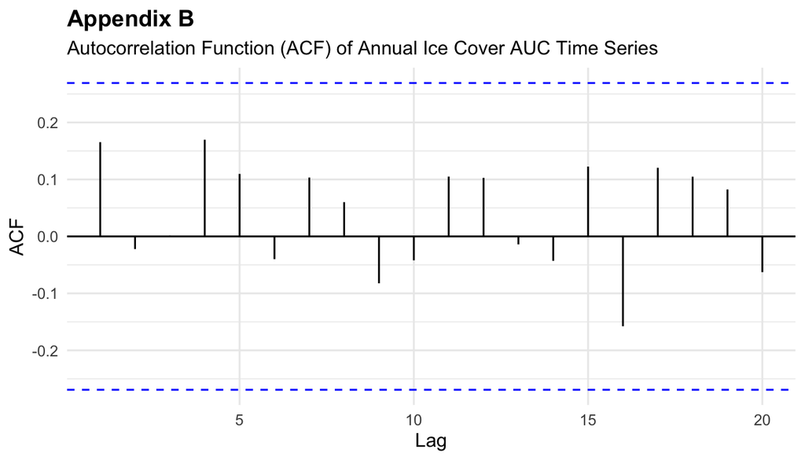

The plot above displays the autocorrelation function for the annual cumulative ice cover (AUC) series. The vertical bars represent the correlation coefficients at various temporal lags, while the dashed blue lines indicate the 95% confidence intervals for white noise ($\pm 1.96/\sqrt{N}$). As observed, all autocorrelation coefficients fall well within the significance bounds. This lack of significant serial correlation suggests that the annual ice cover metrics are effectively independent from year to year.